# Rental Bikes Amount Factors Analysis

Tian Ni

2022-11-28

## Intro and Data visualization

**For this project, given dataset is collected through the Capital bikesharing system of 2011-2012, includes rental bike count, which is interested feature, and other weather and seasonal information. The initial target is to investigate significant factors which would effect the rental bike count, and their importance.**

```
##   instant     dteday season yr mnth holiday weekday workingday weathersit
## 1       1 2011-01-01      1  0    1       0       6          0          2
## 2       2 2011-01-02      1  0    1       0       0          0          2
## 3       3 2011-01-03      1  0    1       0       1          1          1
## 4       4 2011-01-04      1  0    1       0       2          1          1
## 5       5 2011-01-05      1  0    1       0       3          1          1
## 6       6 2011-01-06      1  0    1       0       4          1          1
##       temp    atemp      hum windspeed casual registered  cnt
## 1 0.344167 0.363625 0.805833 0.1604460    331        654  985
## 2 0.363478 0.353739 0.696087 0.2485390    131        670  801
## 3 0.196364 0.189405 0.437273 0.2483090    120       1229 1349
## 4 0.200000 0.212122 0.590435 0.1602960    108       1454 1562
## 5 0.226957 0.229270 0.436957 0.1869000     82       1518 1600
## 6 0.204348 0.233209 0.518261 0.0895652     88       1518 1606
```

For weathersit:

1. Clear, Few clouds, Partly cloudy, Partly cloudy
2. Mist + Cloudy, Mist + Broken clouds, Mist + Few clouds, Mist
3. Light Snow, Light Rain + Thunderstorm + Scattered clouds, Light Rain + Scattered clouds
4. Heavy Rain + Ice Pallets + Thunderstorm + Mist, Snow + Fog

Below is a histogram plot of cnt vs season:

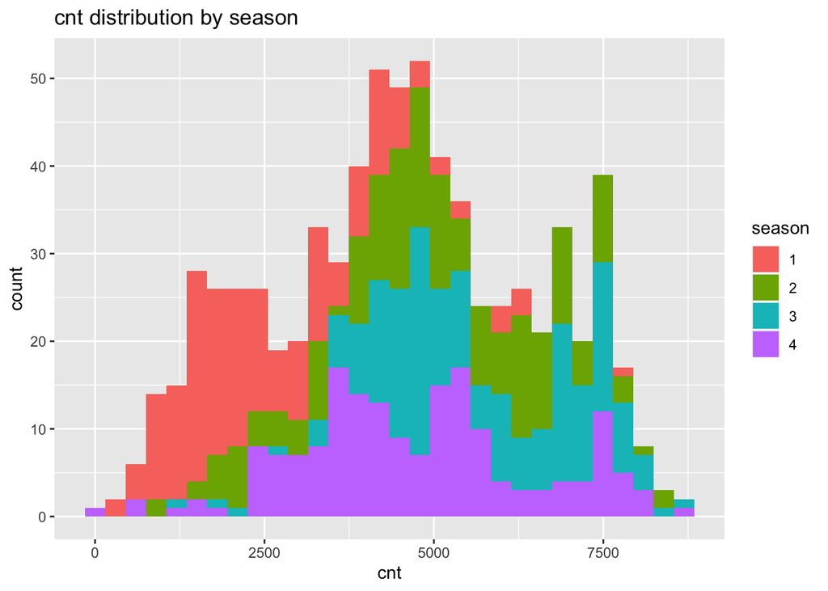

Below is the scatter plot of Rental Bike Count vs Temperature:

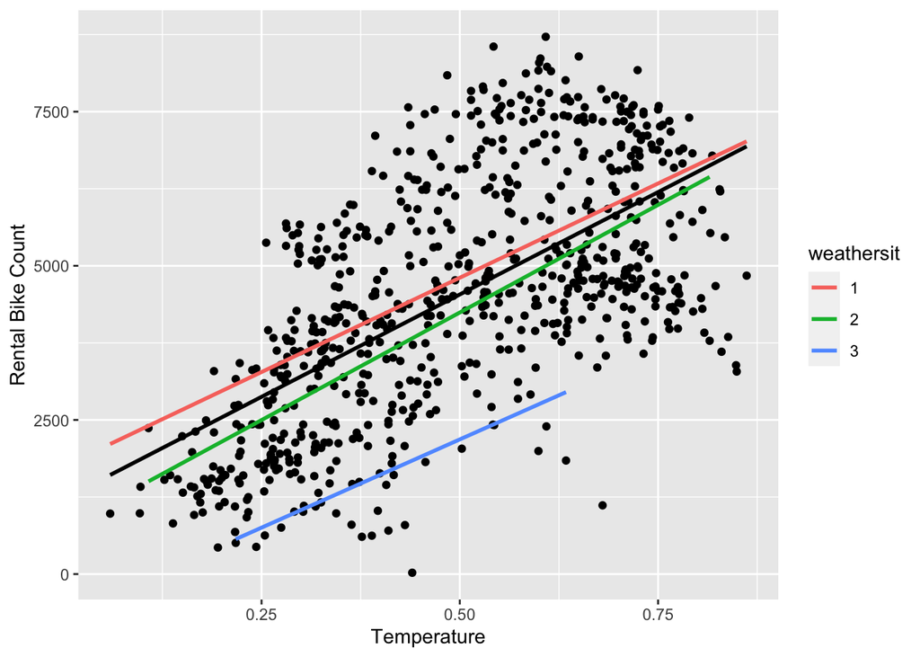

We can see there is clear positive relationship between rental bike count and temperature. Rental bike count may increase with the increasing of temperature.

And more…

## Data Pre-processing

#### Remove redundant variables

I observe that interested response equals registered user count plus casual user count, for better model fitting, I decided to remove these two attributes from latter analysis. Also, instant and dteday are just index and date recorded, also remove them.

#### Normalized back some numerical variables

Some numerical attributes(temperature, feeeling temperature, humidity and wind speed) in the dataset were given normalized and to make better understanding of our latter estimated coefficients, we need first normalized back those values to their original values.

## Methods and Results

Lasso Regression, Random Frest, Linear Regression

#### Lasso

```
## 12 x 2 sparse Matrix of class "dgCMatrix"
##                     s1          s1
## (Intercept) 1247.13580 1001.580371
## season       456.15628  315.826330
## yr          2044.40905 1872.864632
## mnth         -22.74064    .
## holiday     -264.90643    .
## weekday       74.88817   24.485420
## workingday   154.12897    .
## weathersit  -544.28844 -522.056703
## temp           .          .
## atemp        118.21158  110.427934
## hum          -11.91346   -1.479611
## windspeed    -31.01274   -9.316859
```

#### Random Forest

```
##               %IncMSE IncNodePurity
## season      30.617581     152741478
## yr         163.070014     603719676
## mnth        31.868364      91209287
## holiday     -1.581167       4439636
## weekday     10.951383      33765050
## workingday   8.308603       9031318
## weathersit  22.046890      46412184
## temp        25.463550     548796778
## atemp       27.243311     500588123
## hum         37.984613     139316318
## windspeed   15.093291      67080070
```

#### Linear Regression

I first used Best Subset Selection to find the best model which gives minimum AIC/BIC/Marrow’s Cp value. The final model is
$$Bike Count \sim
season+yr+weekday+weathersit+atemp+hum+windspeed$$
;

```
##               Estimate Std. Error   t value      Pr(>|t|)
## (Intercept) 1345.48986 254.629048  5.284118  1.793478e-07
## season       398.32329  36.059937 11.046145  7.263931e-26
## yr          2047.26671  73.787397 27.745479 2.730601e-108
## weekday       79.36898  18.233240  4.352983  1.588806e-05
## weathersit  -524.56401  93.711503 -5.597648  3.362551e-08
## atemp        119.91053   4.889275 24.525218  1.543787e-91
## hum          -13.07610   3.754758 -3.482541  5.342918e-04
## windspeed    -32.03029   7.582475 -4.224253  2.785637e-05
```

## Conclusion

Below is the Mean Squared Error(MSE) calculated from the three models:

```
##               [,1]
## MSE_lasso 743810.5
## MSE_rf    496303.7
## MSE_lr    703279.4
```

We can see that random forest model gives lowest MSE while lasso gives highest MSE.

Based on these three models, we conclude that: **feeling temperature, season, weekday, weather condition, humidity, wind speed, year** are relatively important for rental bike count, where year, temperature and humidity might be the most important variables.